# InVivoStat Graphics

## Selected variables

The variable Time2 has been selected as the response and the variable Resp2 has been selected to define the X-axis. The variables Cat1 and Time 1 have been selected as the categorisation factors.

## Categorised scatterplot

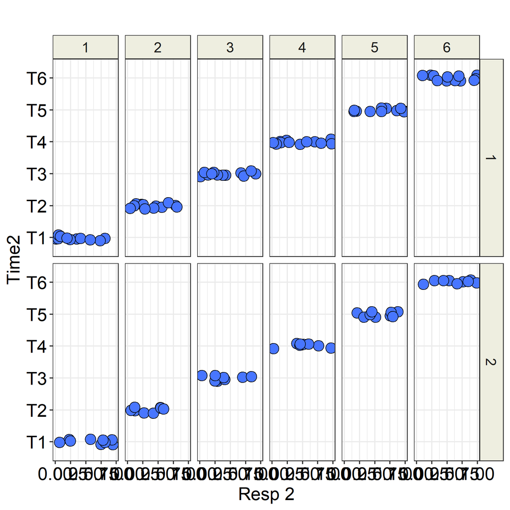

Warning: As one of the variables is non-numeric, no correlation analysis has been performed.

For more information on the theoretical approaches that are implemented within this module, see Bate and Clark (2014).

## Statistical references

Bate, S.T. and Clark, R.A. (2014). The Design and Statistical Analysis of Animal Experiments. Cambridge University Press.

## R references

R Development Core Team (2013). R: A language and environment for statistical computing. R Foundation for Statistical Computing, Vienna, Austria. URL http://www.R-project.org.

Barret Schloerke, Jason Crowley, Di Cook, Heike Hofmann, Hadley Wickham, Francois Briatte, Moritz Marbach and Edwin Thoen (2014). GGally: Extension to ggplot2. R package version 0.4.5. http://CRAN.R-project.org/package=GGally

Erich Neuwirth (2011). RColorBrewer: ColorBrewer palettes. R package version 1.0-5. http://CRAN.R-project.org/package=RColorBrewer

H. Wickham. ggplot2: elegant graphics for data analysis. Springer New York, 2009.

Kamil Slowikowski (2018). ggrepel: Automatically Position Non-Overlapping Text Labels with 'ggplot2'. R package version 0.8.0. https://CRAN.R-project.org/package=ggrepel

H. Wickham. Reshaping data with the reshape package. Journal of Statistical Software, 21(12), 2007.

Hadley Wickham (2011). The Split-Apply-Combine Strategy for Data Analysis. Journal of Statistical Software, 40(1), 1-29. URL http://www.jstatsoft.org/v40/i01/.

Hadley Wickham (2012). scales: Scale functions for graphics. R package version 0.2.3. http://CRAN.R-project.org/package=scales

Lecoutre, Eric (2003). The R2HTML Package. R News, Vol 3. N. 3, Vienna, Austria.

Louis Kates and Thomas Petzoldt (2012). proto: Prototype object-based programming. R package version 0.3-10. http://CRAN.R-project.org/package=proto

## Analysis dataset

| Observation | Time2 | Resp2 | Cat1 | Time 1 |
| --- | --- | --- | --- | --- |
| 1 | T1 | 0.012 | 1 | 1 |
| 2 | T1 | 0.048 | 1 | 1 |
| 3 | T1 | 0.052 | 1 | 1 |
| 4 | T1 | 0.076 | 1 | 1 |
| 5 | T1 | 0.085 | 1 | 1 |
| 6 | T1 | 0.190 | 1 | 1 |
| 7 | T1 | 0.243 | 1 | 1 |
| 8 | T1 | 0.353 | 1 | 1 |
| 9 | T1 | 0.412 | 1 | 1 |
| 10 | T1 | 0.572 | 1 | 1 |
| 11 | T1 | 0.731 | 1 | 1 |
| 12 | T1 | 0.811 | 1 | 1 |
| 13 | T2 | 0.041 | 1 | 2 |
| 14 | T2 | 0.108 | 1 | 2 |
| 15 | T2 | 0.139 | 1 | 2 |
| 16 | T2 | 0.234 | 1 | 2 |
| 17 | T2 | 0.253 | 1 | 2 |
| 18 | T2 | 0.281 | 1 | 2 |
| 19 | T2 | 0.427 | 1 | 2 |
| 20 | T2 | 0.466 | 1 | 2 |
| 21 | T2 | 0.563 | 1 | 2 |
| 22 | T2 | 0.667 | 1 | 2 |
| 23 | T2 | 0.785 | 1 | 2 |
| 24 | T2 | 0.809 | 1 | 2 |
| 25 | T3 | 0.008 | 1 | 3 |
| 26 | T3 | 0.076 | 1 | 3 |
| 27 | T3 | 0.134 | 1 | 3 |
| 28 | T3 | 0.197 | 1 | 3 |
| 29 | T3 | 0.226 | 1 | 3 |
| 30 | T3 | 0.290 | 1 | 3 |

[output cut: 96 more lines]

## Analysis options

Response variable: Time2

X-axis variable: Resp2

First categorisation factor: Cat1

Second categorisation factor: Time 1

Categorised gragh style: Separate

Display legend (Y/N): Y

X-axis title (except for Histogram): Resp 2

Y-axis title: Time2

Output Scatterplot (Y/N): Y

Apply jitter function (Y/N): Y